**Extensive form games**

# 1 Getting Going

First open R or Rstudio and install the hop package from github (make sure you have devtools installed to be able to run the below command):

```r
devtools::install_github("macartan/hop")
```

Then load it up:

```r
library(hop)
```

# 2 Game trees

The `gt_tree` function graphs game trees given a full specification of an extensive form game with complete information. To define an extensive form game we need to define:

- $H$: a set of histories – that is all the possible paths that can be followed
- $P$: a player function that says what player moves at what point in each history
- $U$: Utilities awarded to players at the end of each history

## 2.1 Illustration 1; Sequential Chicken

Here is a simple example. Lets imagine a Chicken game played out over time. H, P and U, are defined as follows:

```r
H <- matrix(c("0", "0", "0", "0", "C", "C", "D", "D", "C", "D",  "C", "D"),4)
P <- matrix(c(rep(1,4), rep(2,4)),4)
U <- matrix(c(1,0,2,-1,1,2, 0, -1), 4)
```

Then the game tree looks like this:

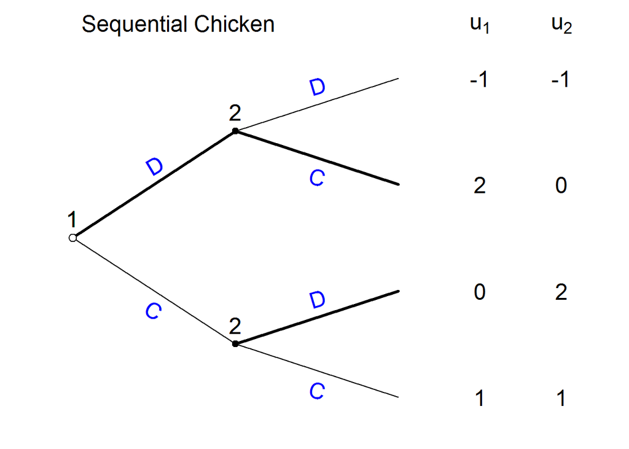

```r
gt_tree(H,U,P, title = "Sequential Chicken", solution = TRUE)
```

Note that `gt_tree` interprets the set of histories as a tree; it figures out the branches based on when the histories depart from each other and the nodes from the player function. The underlying data looks like this:

History:

```r
rownames(H) <- c("H1", "H2", "H3", "H4")
kable(H, col.names = c("T0", "T1", "T2"))
```

|  | T0 | T1 | T2 |
| --- | --- | --- | --- |
| H1 | 0 | C | C |
| H2 | 0 | C | D |
| H3 | 0 | D | C |
| H4 | 0 | D | D |

Player Function:

```r
rownames(P) <- c("H1", "H2", "H3", "H4")
kable(P, col.names = c("T1", "T2"))
```

|  | T1 | T2 |
| --- | --- | --- |
| H1 | 1 | 2 |
| H2 | 1 | 2 |
| H3 | 1 | 2 |
| H4 | 1 | 2 |

Utilities:

```r
rownames(U) <- c("H1", "H2", "H3", "H4")
kable(U, col.names =c("U1", "U2"))
```

|  | U1 | U2 |
| --- | --- | --- |
| H1 | 1 | 1 |
| H2 | 0 | 2 |
| H3 | 2 | 0 |
| H4 | -1 | -1 |

## 2.2 Illustration 2: The Hostage Game

The introductory text describes a hostage game in which options depend on past history.

Here is the graph with the solution:

```r
gt_tree(
      H = matrix(c("Take hostages", "Take hostages", "Don't take", "Pay Ransom", "Don't pay", ""),3),
      U = matrix(c(1,-1,0,-1,-2,0), 3),
      P = matrix(c(rep(1,3), c(2,2,1)),3),
      solution=TRUE,
      player.names=c("Militants", "Gov")
      )
```

```
## [1] "Initial history column added"
```

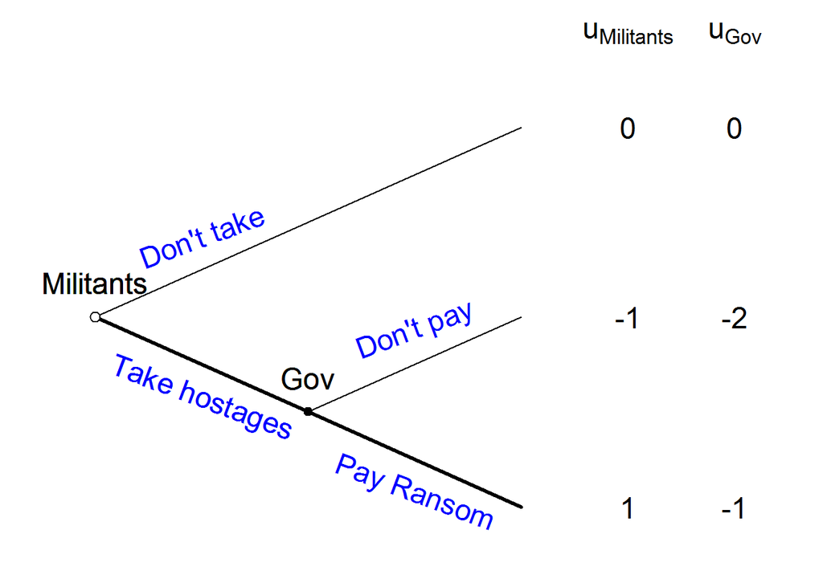

# 3 More complex games

The function can allow much more complex games; the key chllenge is to be able to write out all the histories. Somestimes these histories can be generated in an automated way to make families of more complex games.

```r
centipede <- function(n, ...){
        H <- matrix("C", n+1, n+1)
        H[lower.tri(H)] <- "D"
        H <- H[,n:1]
        U <- cbind(U1 = ((n+1):1) + 2*((n+1):1)%%2 - 2,
                  U2 = ((n+1):1) - 2*((n+1):1)%%2 + 1)
        P <-  t(replicate(n+1, rev(rep(1:2, length = n+1))))
        P[lower.tri(P)] <- t(P)[lower.tri(P)]
        P <- t(P)[,(n+1):1]
        gt_tree(H,U,P, ...)
        }
```

Now use this to graph a short and a long centipede game:

```r
centipede(n = 3, solution = TRUE)
```

```
## [1] "Initial history column added"
```

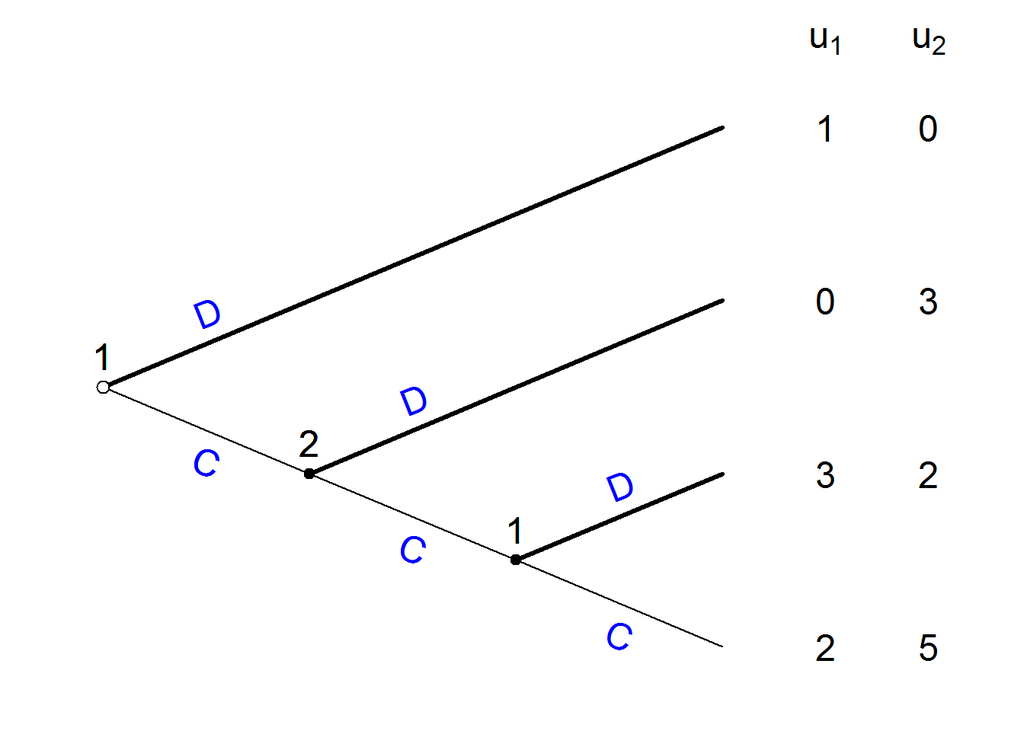

```r
centipede(n = 8, solution = TRUE, textsize=.75)
```

```
## [1] "Initial history column added"
```

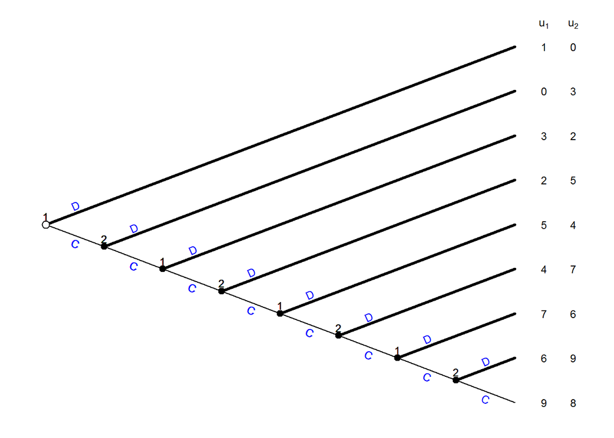

# 4 Adding and forcing solutions

You can add or remove solutions using the solution argument. The sequential chicken without a solution is drawn like this:

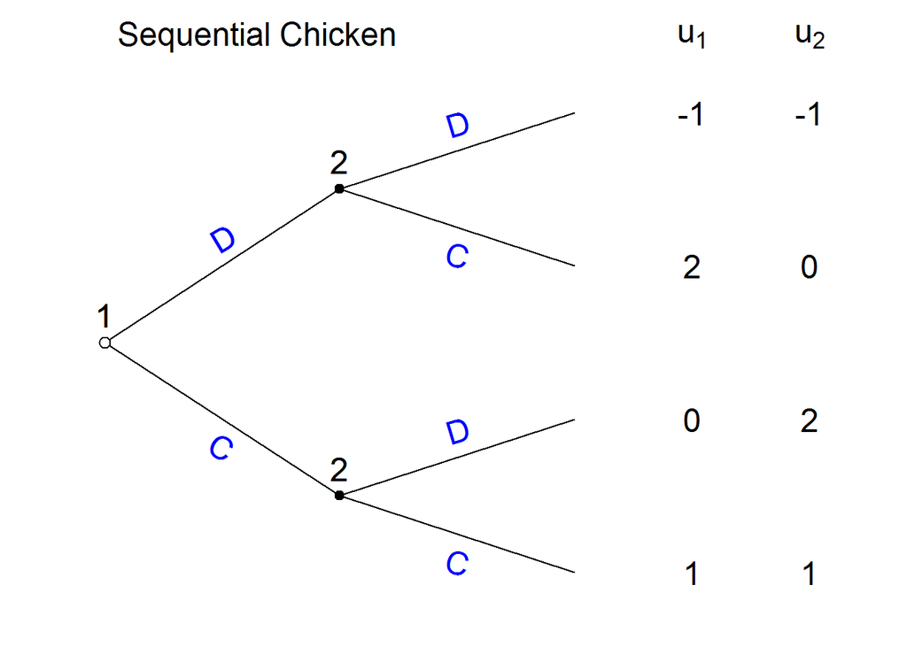

```r
gt_tree(H,U,P, title = "Sequential Chicken", solution = FALSE)
```

The solution will however generally not appear for a non-generic game:

```r
U[1,2] <- 0
gt_tree(H,U,P, title = "Non-generic", solution = TRUE)
```

```
## [1] "Game is not generic and solution not attempted."
```

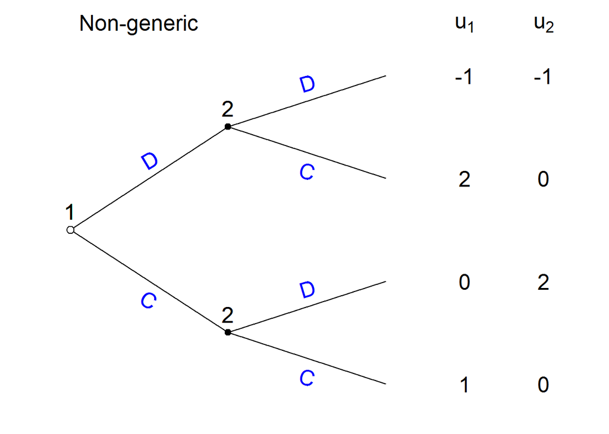

Unless forced:

```r
gt_tree(H,U,P, title = "Non-generic", solution = TRUE, force_solution = TRUE)
```

```
## [1] "Warning: Solution attempted even though game is not generic"
```

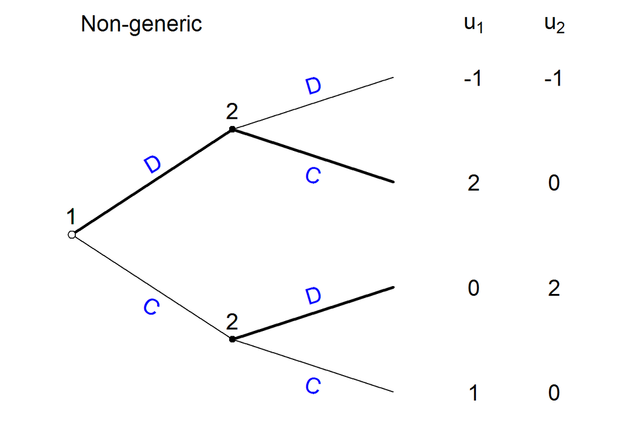

This can however have undesireable consequences:

```r
U[1,2] <- 2
gt_tree(H,U,P, title = "Non-generic", solution = TRUE, force_solution = TRUE)
```

```
## [1] "Warning: Solution attempted even though game is not generic"
```

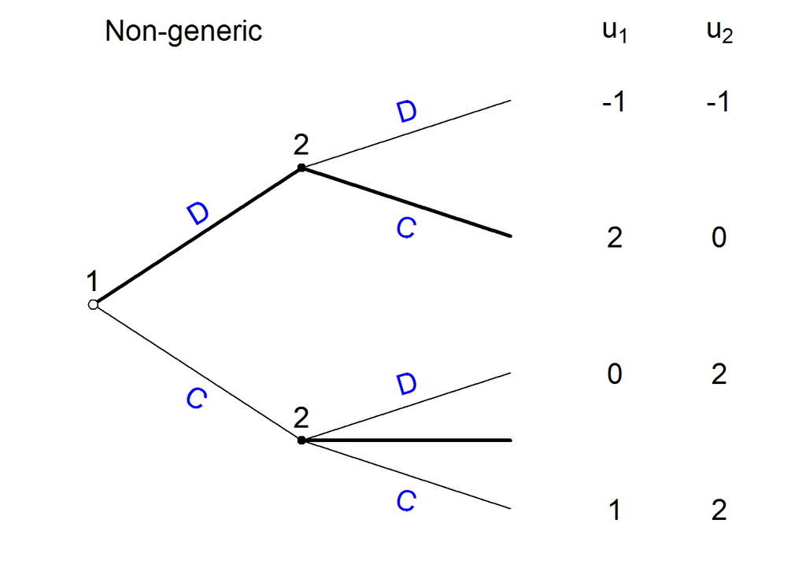

# 5 Formatting

You can do a reasonable amount of formatting in terms of specifying sizes and colors. eg:

```r
gt_tree(H,U,P,
  title = "Sequential Chicken",
  force_solution = TRUE,
  player.names=c("Jack", "Jill"),
  textsize  = 1,
  titlesize = 2,
  utextsize = 1.25,
  btextsize = 1.5,
  slopetext = FALSE,

  branchcol = "orange",
  actioncol = "black",
  titlecol  = "grey",
  playercol = "red",
  solutioncol = "darkorange"
        )
```

```
## [1] "Warning: Solution attempted even though game is not generic"
```

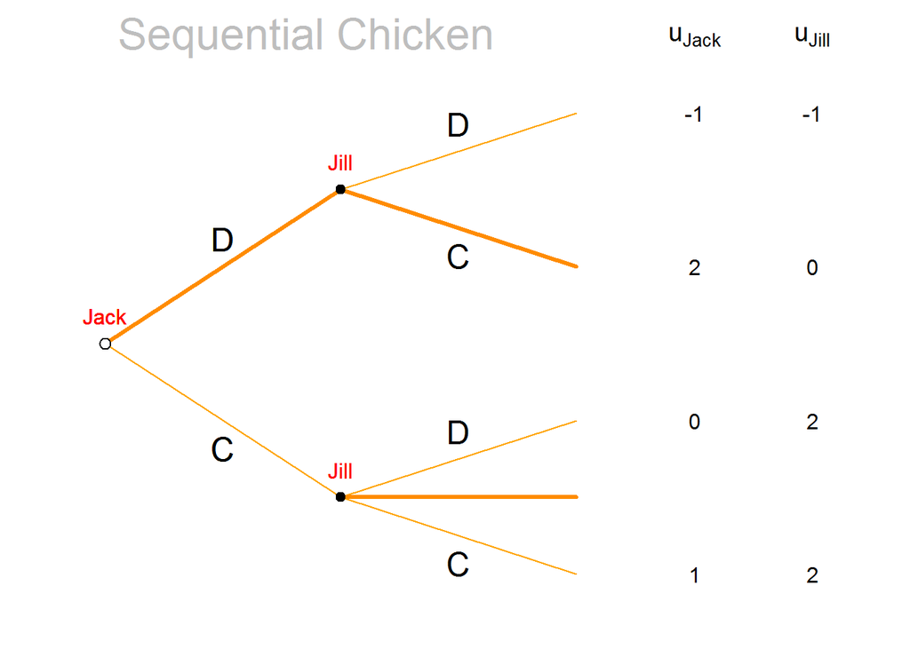

# 6 Limitations

Besides being in alpha stage the main limitations of this function the fact that it cannot solve when there are multiple equilibria and payoff indifferences; and it cannot solve games of incomplete information. Even still it can be used to graph these and then then information sets and solutions can be superimposed.